# protokoll

### Aufgabe 3

Berechnen Sie aus den Messwerten für $I$, $U$, $I_{k}$ und $U_{q}$ die normierten Leistungskurven (bezogen auf die Leistung $P_{k} = I_{k}^{2} \cdot R_{i}$):

$\frac{P_{a}}{P_{k}}$ ; $\frac{P_{i}}{P_{k}}$ ; $\frac{P_{ges}}{P_{k}}$ in Abhängigkeit von $\frac{R_{a}}{R_{i}}$

und stellen Sie diese graphisch dar.

#### Eingabe Messwerte

```python
x = np.array([0, 0.2, 0.4, 0.6, 0.8, 1, 1.5, 2, 2.5, 3, 3.5, 4, 4.5, 5])
```

```python
xplot = np.array([])
xa = np.array(x)
pa = xa/((1 + xa)**2)
xplot = np.append(xplot, x)
```

```python
pi = 1/((1 + xa)**2)
xplot = np.append(xplot, x)
pa = np.append(pa,pi)
```

```python
pges = 1/(1 + x)
xplot = np.append(xplot, x)
pa = np.append(pa,pges)
```

#### Eingabe Darstellungsparameter

```python
x_g = [0, 7]
p_g = [0, 1]
title = 'normierte Leistungskurven $P_{a}/P_{k}, P_{i}/P_{k}, P_{ges}/P_{k}$'
xl = '$R_{a}/R_{i}$'
yl = ''
name = 'images/gs4.jpg'
```

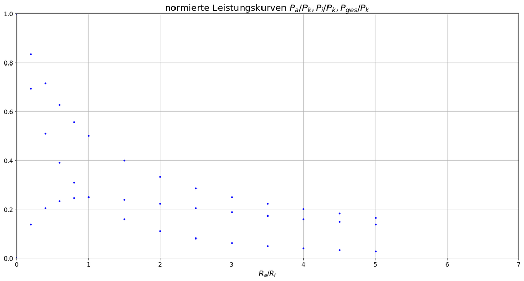

```python
fineprint(xplot, pa, x_g, p_g, title, xl, yl, name)
```

Welche maximale Leistung kann der untersuchte aktive Zweipol abgeben?

```python
pmax = U_q**2/(4 * R_i)
print('maximale abgegebene Leistung: %s W' %  pmax)
```

```
maximale abgegebene Leistung: 12.25 W
```

### Aufgabe 4

Zeichnen Sie das Schaltbild des Netzwerkes am Versuchsplatz ab! Messen Sie mit dem Digitalmultimeter die Einzelwiderstände des Netzwerkes und den Ersatzinnenwiderstand $R_{iers}$ bei überbrückten Quellspannungen! Kontrollieren Sie den gemessenen $R_{iers}$ durch Berechnung aus den Einzelwiderständen!

### Aufgabe 5

Messen Sie die Quellspannungen $U_{q}$ aller Spannungsquellen und die Leerlaufspannung $U_{lAB}$ des Netzwerkes!

### Aufgabe 6

Überprüfen Sie die Anwendbarkeit des Überlagerungssatzes durch Messung der von den einzelnen Quellspannungen $U_{q}$ hervorgerufenen Teilzweigströme $I_{\nu AB}$ und des Gesamtzweigstromes $I_{AB}$!